# (Adv) Web Programming

Ganesh Chandrasekaran

Summer 2020

**Welcome**

### You are not going to learn Technology, you are going to experience Technology.

```
1. Objectives
    Not just web programming, learn what it takes to become a web programmer. Learn related tools.

2. Challenges with this course.
    Remote - Summer

3. Class classification
    Grad & Under Grad

4. My Expectation from you.
    Attend classes - Participate in discussions - Ask me questions so you learn trick of the trade.
    Chat and tell me what kind of books you read. I will return the same.
    Feel at ease.

5. Syllabus
```

**Stackoverflow Survey - Popular Scritping language ?** [^1]

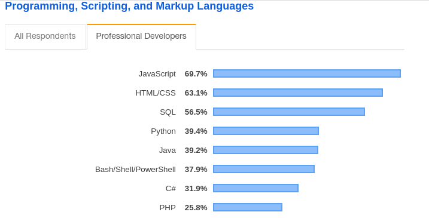

**Stackoverflow Survey - Popular Framework ?**

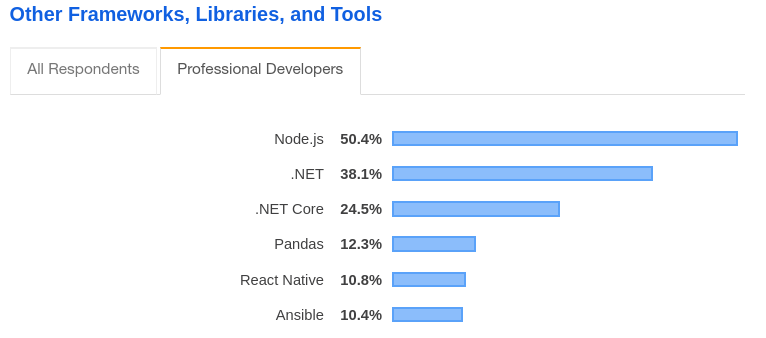

**Stackoverflow Survey - Popular Platform ?**

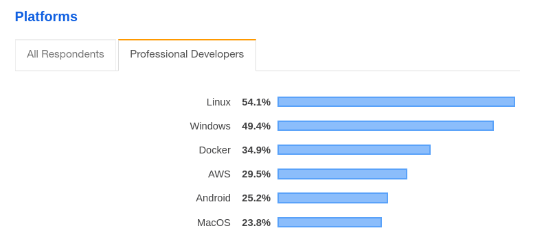

**Related Technology**

[figure not shown]

What is Monolithic Application ?

A monolithic application is self-contained, and independent from other computing applications

**Typical Monolithic Application**

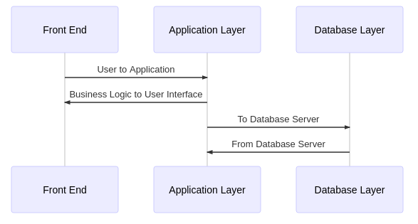

**Benefits**

```
1. Easy to develop.
2. Easy to test.
3. Simple to deploy.
4. Relatively easier to scale.
```

**Disadvantages**

```
- Application too big.
- For every change entire application needs to be deployed.
- Bug in one system can bring down entire system.
- Very hard to introduce new technology.
```

**Technology heading towards**

```
1. Robotics
2. AI
3. IoT
4. Blockchain
5. 3D Printing
6. Internet / Mobile Apps
7. Autonomous Cars - VANET Routing
8. VR / AR - Virtual Reality / Augmented Reality
9. Wireless
10. Quantum Computing
11. 5G
12. Voice Assistant (Comcast Voice Remote, Siri, Alexa ...)
13. Cyber Security
```

**What is the common technology needed for all of the above ?**

```
1. Data
2. Visual Interface
```

**Data**

```
1. Transactional Data
2. Structured Data
3. Semi Structured Data
4. Un Structured Data
```

(this is not Database course so lets now worry about it)

**Visual Interface**

```
1. Client App
2. Mobile App
3. Web App
```

**Web Development**

```
1. Front End Design
2. Back End Development
3. Dev Ops
4. API Development
```

**What does the term “Stack” means to you ?**

```
- Stack (Data Structures)
- StackOverflow ?
- Popuar LAMP Stack (Linux Apache Mysql Php / Python / Perl)
- Full Stack
```

**What is Full Stack Development** ?

```
- Front End Design
- Back End Development
- Database Development
- Web Server Configuration
- Search Engine Optimization
- API Development
```

**Front End Developer** [^2]

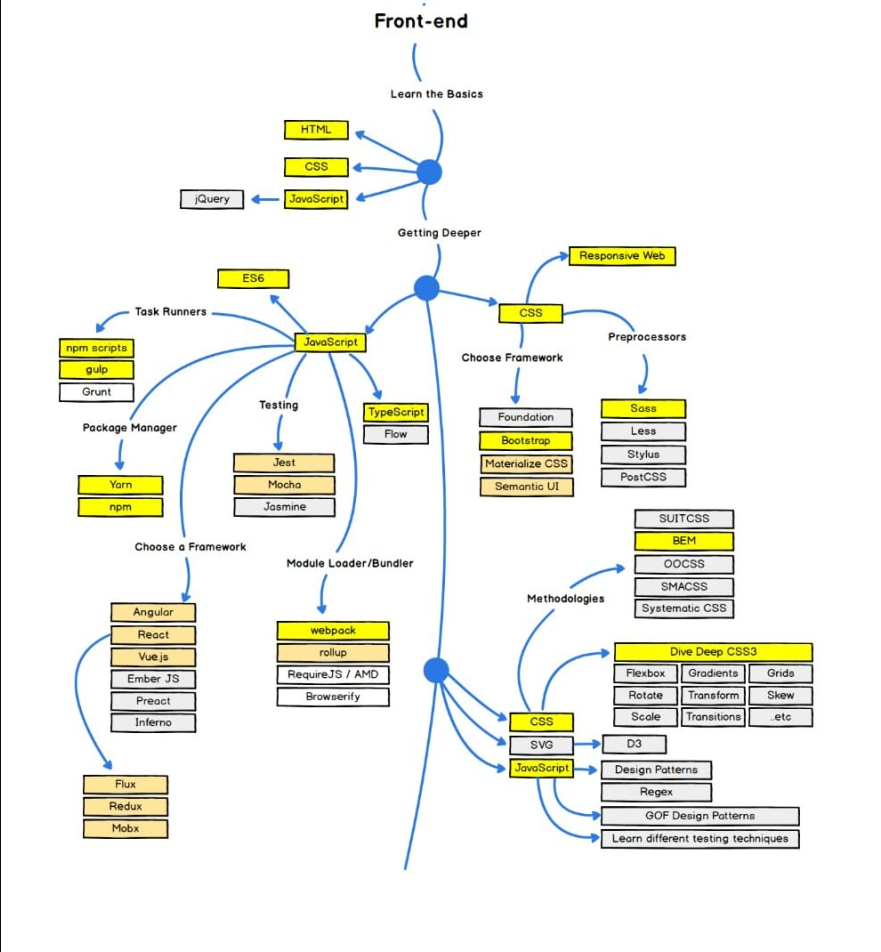

Front End Developer

**Back End Developer**

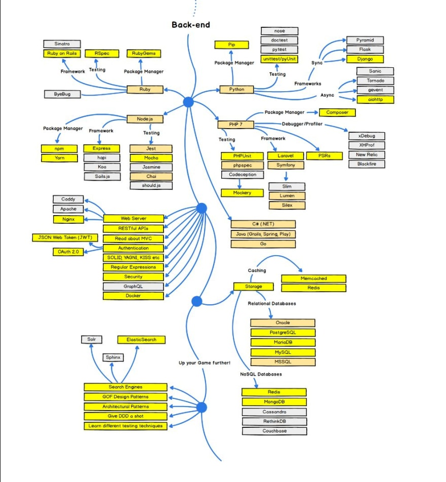

Back End Developer

**DevOps**

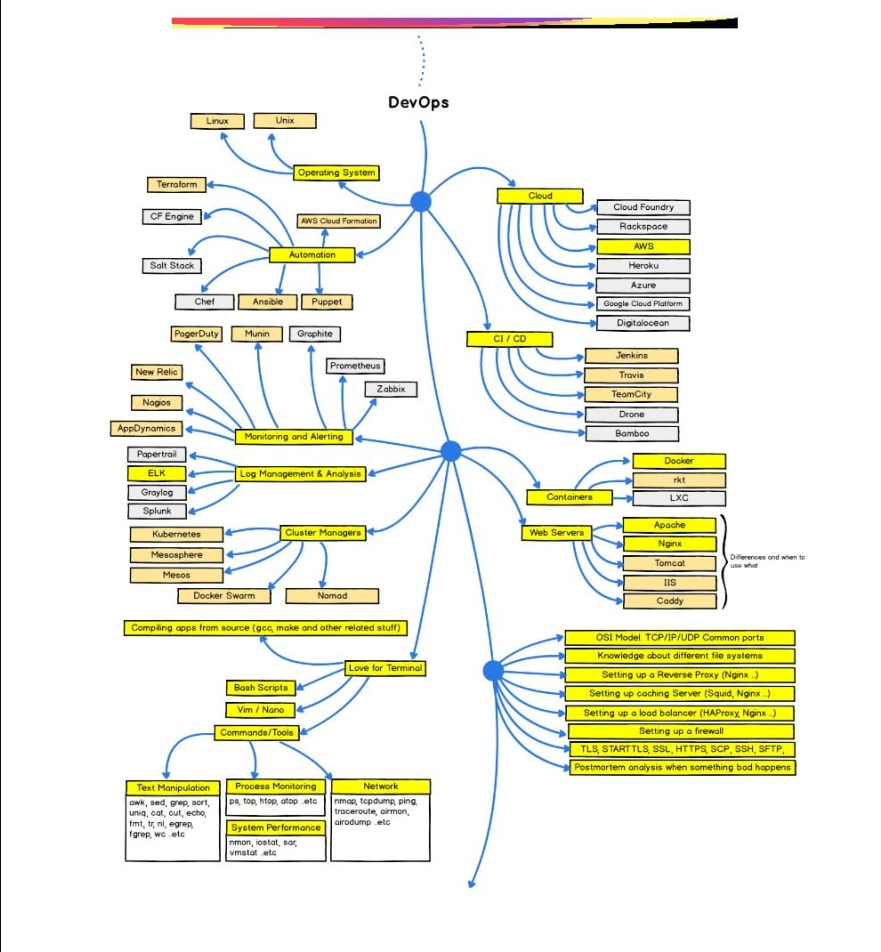

Dev Ops Support

**GPL / DSL**

*GPL : General Programming Language*

*Examples of GPL*

Python | C++ | Java | Ruby….

*DSL : Domain Specific Language*

*Examples of DSL*

```
- SQL - Structured Query Language
- HTML - Hyper Text Markup Language
- CSS - Cascading Style Sheet
- LaTEX
- MD - Mark Down ....
```

** Example : In Script **

```
firstName.toUpperCase() + ' ' + lastName.toUppercase()

In CSS

text.transform : capitalize
```

[Click here to list complete List of DSL](https://tomassetti.me/domain-specific-languages/)

**DSL Advantages**

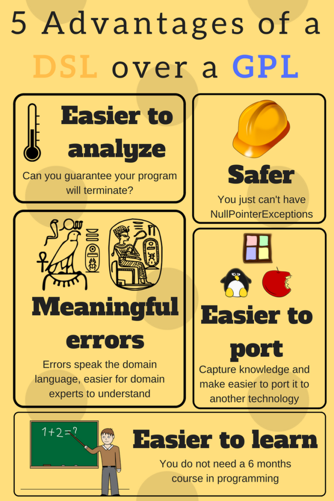

DSL Advantages

**Markup Language**

Markup language is a system for annontating a document in a way that is syntactically distinguishable from other text.

In real world, paper text

Color Pens, Highlighter, Underline..

In Computer world, its Hyper Text

Hyper : Uplift / Lively / Refreshing Job of diffrentiating (from simple text) is done by `<tags>`

```
    Example of Tags

    <h1> Heading 1 </h1>
    <h2> Heading 2 </h2>
    <h3> Heading 3 </h3>
    <strong> Bold Text </strong>
    <i> Italicized Text </i>
```

**Markdown Language**

Lightweight language used with plain text to create Rich text output.

No fancy editors needed for creating Rich text.

Popularly used in Githubs (readme.md), Technical writers use this a lot

```
- It's Easy
- It's Fast
- It's Cross Platform
- It's Easy to read (without parsing)
- It's convertable
```

*Note : This whole page was created using Markdown*

```
    Example of Markdown

    # H1
    ## H2
    ### H3

    **Bold Text**

    *Italicized Text*

    >blockquote
```

**Mermaid**

Text Alternative to Visio / Paint

```
- Simple
- Scalable
- Scriptable
- On the fly
```

*Use Cases*

```
- Diagrams
- Flowcharts
- Sequence Diagrams
- Charts
```

*Note : Monolithic diagram was built using Mermaid

**Images**

Image Types

JPG - Joint Photographic Expert Group

GIF - Graphic Interchange Format

PNG - Portaable Network Graphic

SVG - Scalable Vector Graphic

**SVG Whats Special**

```
- XML based, gaining popularity in recent years.
- Basically Text files that describes lines, curves, colors.
- Its human readable, can be modified easily manually as well as programatically.
- Its a W3C standard.
- Can be indexed and searched.
- Small in size.
- Enlarged without loss of quality
```

**SVG Use Cases**

(see demo)

```
- Diagrams
- Logos - Icons
- Animations
- Charts / Graphs / Maps
```

**SVG How to create one**

```
- Adobe Illustrator
- Inkscape
- Online converters for PNG to SVG
- Plotly (Python Library)
- Mermaid (see above)
```

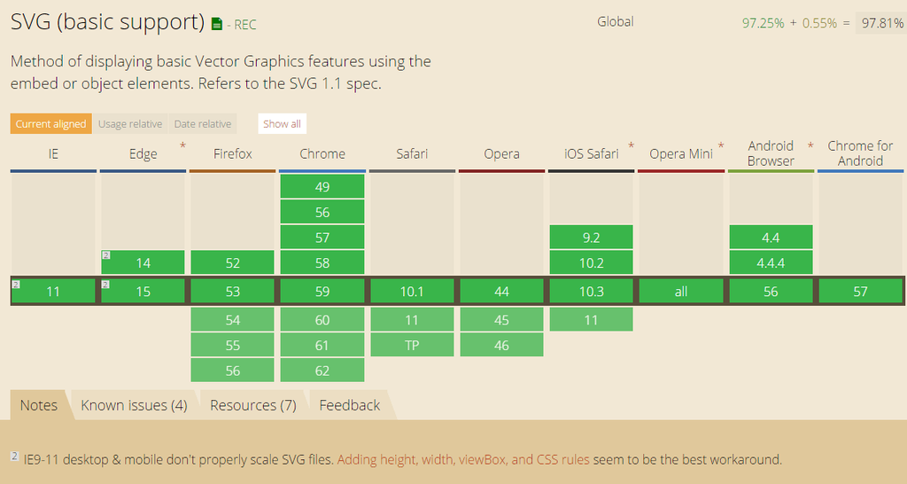

[^1]: Stackoverflow - https://insights.stackoverflow.com/survey/2019#technology
[^2]: Image Source : https://redblink.com/become-full-stack-developer-2019-roadmap/